# 2016 US Bike Share Activity Snapshot

- Introduction
- Posing Questions
- Data Collection and Wrangling
  - Condensing the Trip Data
- Exploratory Data Analysis
  - Statistics
  - Visualizations
- Further Analysis
- Conclusions

## Introduction

Over the past decade, bicycle-sharing systems have been growing in number and popularity in cities across the world. Bicycle-sharing systems allow users to rent bicycles for short trips, typically 30 minutes or less. Thanks to the rise in information technologies, it is easy for a user of the system to access a dock within the system to unlock or return bicycles. These technologies also provide a wealth of data that can be used to explore how these bike-sharing systems are used.

In this project, I am going to perform an exploratory analysis on data provided by [Motivate](https://www.motivateco.com/), a bike-share system provider for many major cities in the United States. I am also going to compare the system usage between three large cities: New York City, Chicago, and Washington, DC. On top of that, I'll try to see if there are any differences within each system for those users that are registered, regular users and those users that are short-term, casual users.

## Posing Questions

Before looking at the actual bike sharing data, we start asking questions by putting ourselves in the stakeholders' shoes.

As a bike sharing business owner, I'd ask:

1. What day during the week has the largest number of bike users (On average)?
2. What are the peak hours during a day?
3. Is there any seasonalities?
4. What is the proportion between registered users and casual users within the 3 cities? And what might be the factors that contribute to such a proportion?
5. What are the features that may affect bike usage? Is there any correlations?
6. Is there any popular dentinations/ routes for both registered users and casual users?

As a user of the bike-share service, I'd ask:

1. How much time could I possibly save if I ride bike (By comparison)?
2. How much money could I possibly save per month (Or in certain time interval) compared to taking other transportations?
3. How could I benefit from being a registered user rather than a casual user?
4. Do I enjoy the same benefits of being a registered user when being in other cities?
5. Is there any transfer/ in-transit packages in which I could enjoy discounts when taking other transportations?
6. How far is the bike pick-up/ drop-off point away from my home/ destination?

## Data Collection and Wrangling

Now it's time to collect and explore our data. In this project, we will focus on the record of individual trips taken in 2016 from our selected cities: New York City, Chicago, and Washington, DC. Each of these cities has a page where we can freely download the trip data.:

- New York City (Citi Bike): [Link](https://www.citibikenyc.com/system-data)
- Chicago (Divvy): [Link](https://www.divvybikes.com/system-data)
- Washington, DC (Capital Bikeshare): [Link](https://www.capitalbikeshare.com/system-data)

If you visit these pages, you will notice that each city has a different way of delivering its data. Chicago updates with new data twice a year, Washington DC is quarterly, and New York City is monthly.

There is a lot of data for us to investigate, so it's a good idea to start off by looking at one entry from each of the cities we're going to analyze.

```python
## import all necessary packages and functions.
import csv # read and write csv files
from datetime import datetime # operations to parse dates
from pprint import pprint # use to print data structures like dictionaries in
                          # a nicer way than the base print function.
```

```python
def print_first_point(filename):
    """
    This function prints and returns the first data point (second row) from
    a csv file that includes a header row.
    """
    # print city name for reference
    city = filename.split('-')[0].split('/')[-1]
    print('\nCity: {}'.format(city))

    with open(filename, 'r') as f_in:
        ## Use the csv library to set up a DictReader object. ##
        trip_reader = csv.DictReader(f_in)

        ## Use a function on the DictReader object to read the     ##
        ## first trip from the data file and store it in a variable.     ##
        first_trip = next(trip_reader)

        ## Use the pprint library to print the first trip. ##
        pprint(first_trip)

    # output city name and first trip for later testing
    return (city, first_trip)

# list of files for each city
data_files = ['./data/NYC-CitiBike-2016.csv',
              './data/Chicago-Divvy-2016.csv',
              './data/Washington-CapitalBikeshare-2016.csv',]

# print the first trip from each file, store in dictionary
example_trips = {}
for data_file in data_files:
    city, first_trip = print_first_point(data_file)
    example_trips[city] = first_trip
```

```
City: NYC
OrderedDict([('tripduration', '839'),
             ('starttime', '1/1/2016 00:09:55'),
             ('stoptime', '1/1/2016 00:23:54'),
             ('start station id', '532'),
             ('start station name', 'S 5 Pl & S 4 St'),
             ('start station latitude', '40.710451'),
             ('start station longitude', '-73.960876'),
             ('end station id', '401'),
             ('end station name', 'Allen St & Rivington St'),
             ('end station latitude', '40.72019576'),
             ('end station longitude', '-73.98997825'),
             ('bikeid', '17109'),
             ('usertype', 'Customer'),
             ('birth year', ''),
             ('gender', '0')])

City: Chicago
OrderedDict([('trip_id', '9080545'),
             ('starttime', '3/31/2016 23:30'),
             ('stoptime', '3/31/2016 23:46'),
             ('bikeid', '2295'),
             ('tripduration', '926'),
             ('from_station_id', '156'),
             ('from_station_name', 'Clark St & Wellington Ave'),
             ('to_station_id', '166'),
             ('to_station_name', 'Ashland Ave & Wrightwood Ave'),
             ('usertype', 'Subscriber'),
             ('gender', 'Male'),
             ('birthyear', '1990')])

City: Washington
OrderedDict([('Duration (ms)', '427387'),
             ('Start date', '3/31/2016 22:57'),
             ('End date', '3/31/2016 23:04'),
             ('Start station number', '31602'),
             ('Start station', 'Park Rd & Holmead Pl NW'),
             ('End station number', '31207'),
             ('End station', 'Georgia Ave and Fairmont St NW'),
             ('Bike number', 'W20842'),
             ('Member Type', 'Registered')])
```

### Condensing the Trip Data

It should also be observable from the above printout that each city provides different information. Even where the information is the same, the column names and formats are sometimes different. To make things as simple as possible when we get to the actual exploration, we should trim and clean the data. Cleaning the data makes sure that the data formats across the cities are consistent, while trimming focuses only on the parts of the data we are most interested in to make the exploration easier to work with.

We will generate new data files with five values of interest for each trip: trip duration, starting month, starting hour, day of the week, and user type. Each of these may require additional wrangling depending on the city:

- **Duration**: This has been given to us in seconds (New York, Chicago) or milliseconds (Washington). A more natural unit of analysis will be if all the trip durations are given in terms of minutes.
- **Month**, **Hour**, **Day of Week**: Ridership volume is likely to change based on the season, time of day, and whether it is a weekday or weekend. Use the start time of the trip to obtain these values. The New York City data includes the seconds in their timestamps, while Washington and Chicago do not.
- **User Type**: It is possible that users who are subscribed to a bike-share system will have different patterns of use compared to users who only have temporary passes. Washington divides its users into two types: 'Registered' for users with annual, monthly, and other longer-term subscriptions, and 'Casual', for users with 24-hour, 3-day, and other short-term passes. The New York and Chicago data uses 'Subscriber' and 'Customer' for these groups, respectively. For consistency, you will convert the Washington labels to match the other two.

We are going to create some helper functions to address each of the cleaning tasks described above.

```python
def duration_in_mins(datum, city):
    """
    Takes as input a dictionary containing info about a single trip (datum) and
    its origin city (city) and returns the trip duration in units of minutes.
    """

    if city == 'NYC':
        duration = float(datum['tripduration']) / 60
    elif city == 'Chicago':
        duration = float(datum['tripduration']) / 60
    elif city == 'Washington':
        duration = float(datum['Duration (ms)']) / 60000
    return duration


# Some tests to check that the code works. There should be no output if all of
# the assertions pass. The `example_trips` dictionary was obtained from when
# we printed the first trip from each of the original data files.
tests = {'NYC': 13.9833,
         'Chicago': 15.4333,
         'Washington': 7.1231}

for city in tests:
    assert abs(duration_in_mins(example_trips[city], city) - tests[city]) < .001
```

```python
def time_of_trip(datum, city):
    """
    Takes as input a dictionary containing info about a single trip (datum) and
    its origin city (city) and returns the month, hour, and day of the week in
    which the trip was made.
    """

    if city == 'NYC':
        starttime = datum['starttime']
        d1 = datetime.strptime(starttime, '%m/%d/%Y %H:%M:%S')
        day_of_week = d1.strftime('%A')
        return (d1.month, d1.hour, day_of_week)
    elif city == 'Chicago':
        starttime = datum['starttime']
        d2 = datetime.strptime(starttime, '%m/%d/%Y %H:%M')
        day_of_week = d2.strftime('%A')
        return (d2.month, d2.hour, day_of_week)
    elif city == 'Washington':
        starttime = datum['Start date']
        d3 = datetime.strptime(starttime, '%m/%d/%Y %H:%M')
        day_of_week = d3.strftime('%A')
        return (d3.month, d3.hour, day_of_week)
    return (month, hour, day_of_week)


# Some tests to check that the code works. There should be no output if all of
# the assertions pass. The `example_trips` dictionary was obtained from when
# we printed the first trip from each of the original data files.
tests = {'NYC': (1, 0, 'Friday'),
         'Chicago': (3, 23, 'Thursday'),
         'Washington': (3, 22, 'Thursday')}

for city in tests:
    assert time_of_trip(example_trips[city], city) == tests[city]
```

```python
def type_of_user(datum, city):
    """
    Takes as input a dictionary containing info about a single trip (datum) and
    its origin city (city) and returns the type of system user that made the
    trip.
    """

    if city == 'NYC':
        user_type = datum['usertype']
    elif city == 'Chicago':
        user_type = datum['usertype']
    elif city == 'Washington':
        if datum['Member Type'] == 'Registered':
            user_type = 'Subscriber'
        else:
            user_type = 'Customer'
    return user_type


# Some tests to check that the code works. There should be no output if all of
# the assertions pass. The `example_trips` dictionary was obtained from when
# we printed the first trip from each of the original data files.
tests = {'NYC': 'Customer',
         'Chicago': 'Subscriber',
         'Washington': 'Subscriber'}

for city in tests:
    assert type_of_user(example_trips[city], city) == tests[city]
```

Now, we are going to use the helper functions written above to create a condensed data file for each city consisting only of the data fields indicated above.

```python
def condense_data(in_file, out_file, city):
    """
    This function takes full data from the specified input file
    and writes the condensed data to a specified output file. The city
    argument determines how the input file will be parsed.
    """

    with open(out_file, 'w') as f_out, open(in_file, 'r') as f_in:
        # set up csv DictWriter object - writer requires column names for the
        # first row as the "fieldnames" argument
        out_colnames = ['duration', 'month', 'hour', 'day_of_week', 'user_type']
        trip_writer = csv.DictWriter(f_out, fieldnames = out_colnames)
        trip_writer.writeheader()

        ## set up csv DictReader object ##
        trip_reader = csv.DictReader(f_in)

        # collect data from and process each row
        for row in trip_reader:
            # set up a dictionary to hold the values for the cleaned and trimmed
            # data point
            new_point = {}

            ## use the helper functions to get the cleaned data from  ##
            ## the original data dictionaries.                              ##
            ## Note that the keys for the new_point dictionary should match ##
            ## the column names set in the DictWriter object above.         ##
            new_point['duration'] = duration_in_mins(row, city)
            new_point['month'] = time_of_trip(row, city)
            new_point['week'] = time_of_trip(row, city)
            new_point['day_of_week'] = time_of_trip(row, city)
            new_point['user_type'] = type_of_user(row, city)

            ## write the processed information to the output file.     ##
            f_out.write("{},".format(new_point['duration']))
            f_out.write("{},".format(new_point['month'][0]))
            f_out.write("{},".format(new_point['week'][1]))
            f_out.write("{},".format(new_point['day_of_week'][2]))
            f_out.write("{}\n".format(new_point['user_type']))
```

```python
# check the work
city_info = {'Washington': {'in_file': './data/Washington-CapitalBikeshare-2016.csv',
                            'out_file': './data/Washington-2016-Summary.csv'},
             'Chicago': {'in_file': './data/Chicago-Divvy-2016.csv',
                         'out_file': './data/Chicago-2016-Summary.csv'},
             'NYC': {'in_file': './data/NYC-CitiBike-2016.csv',
                     'out_file': './data/NYC-2016-Summary.csv'}}

for city, filenames in city_info.items():
    condense_data(filenames['in_file'], filenames['out_file'], city)
    print_first_point(filenames['out_file'])
```

```
City: Washington
OrderedDict([('duration', '7.123116666666666'),
             ('month', '3'),
             ('hour', '22'),
             ('day_of_week', 'Thursday'),
             ('user_type', 'Subscriber')])

City: Chicago
OrderedDict([('duration', '15.433333333333334'),
             ('month', '3'),
             ('hour', '23'),
             ('day_of_week', 'Thursday'),
             ('user_type', 'Subscriber')])

City: NYC
OrderedDict([('duration', '13.983333333333333'),
             ('month', '1'),
             ('hour', '0'),
             ('day_of_week', 'Friday'),
             ('user_type', 'Customer')])
```

## Exploratory Data Analysis

Now that we have the data collected and wrangled, we're ready to start exploring the data. In this section we will write some code to compute descriptive statistics from the data.

### Statistics

**The questions that we need answers for**: Which city has the highest number of trips? Which city has the highest proportion of trips made by subscribers? Which city has the highest proportion of trips made by short-term customers?

**Answer**:  
Washington: (51753, 14573, 66326, 78.0282242257938, 21.971775774206193)  
Chicago: (54982, 17149, 72131, 76.22520136973007, 23.774798630269924)  
NYC: (245896, 30902, 276798, 88.83590199351151, 11.164098006488485)

The city that has the highest number of trips: NYC  
The city that has the highest proportion of trips made by subscribers: NYC  
The city that has the highest proportion of trips made by short-term customers: Chicago

```python
def number_of_trips(filename):
    """
    This function reads in a file with trip data and reports the number of
    trips made by subscribers, customers, and total overall.
    """
    with open(filename, 'r') as f_in:
        # set up csv reader object
        reader = csv.DictReader(f_in)

        # initialize count variables
        n_subscribers = 0
        n_customers = 0

        # tally up ride types
        for row in reader:
            if row['user_type'] == 'Subscriber':
                n_subscribers += 1
            else:
                n_customers += 1

        # compute total number of rides
        n_total = n_subscribers + n_customers
        sub_proportion = (n_subscribers / n_total) * 100
        cus_proportion = (n_customers / n_total) * 100
        # return tallies as a tuple
        return(n_subscribers, n_customers, n_total, sub_proportion, cus_proportion)
```

```python
data_file = ['./data/Washington-2016-Summary.csv', './data/Chicago-2016-Summary.csv', './data/NYC-2016-Summary.csv']

for datafile in data_file:
    print(number_of_trips(datafile))
```

```
(51753, 14573, 66326, 78.0282242257938, 21.971775774206193)
(54982, 17149, 72131, 76.22520136973007, 23.774798630269924)
(245896, 30902, 276798, 88.83590199351151, 11.164098006488485)
```

Now, we are going to write code to continue investigating properties of the data.

Bike-share systems are designed for riders to take short trips. Most of the time, users are allowed to take trips of 30 minutes or less with no additional charges, with overage charges made for trips of longer than that duration.

**The questions that we need answers for**: What is the average trip length for each city? What proportion of rides made in each city are longer than 30 minutes?

**Answer**:

1. What is the average trip length for each city?  
   Washington: 18.93 minutes  
   Chicago: 16.56 minutes  
   NYC: 15.81 minutes
2. What proportion of rides made in each city are longer than 30 minutes?  
   Washington: 10.84%  
   Chicago: 8.33%  
   NYC: 7.3%

```python
## convert the strings      ##
## into an appropriate numeric type before we aggregate data.          ##
def length_of_trips(filename):

    with open(filename, 'r') as f_in:
        # set up csv reader object
        reader = csv.DictReader(f_in)
        number_of_trips = 0
        overage_trips = 0
        total_duration = 0
        for row in reader:
            number_of_trips += 1
            duration = float(row['duration'])
            total_duration = total_duration + duration
            if duration > 30:
                overage_trips += 1

        average_length = total_duration / number_of_trips
        proportion = (overage_trips/number_of_trips)*100

        return (number_of_trips, overage_trips, total_duration, average_length, proportion)
```

```python
data_file = ['./data/Washington-2016-Summary.csv', './data/Chicago-2016-Summary.csv', './data/NYC-2016-Summary.csv']

for datafile in data_file:
    print(length_of_trips(datafile))
```

```
(66326, 7189, 1255741.7716833346, 18.93287355913721, 10.83888671109369)
(72131, 6010, 1194751.1499999992, 16.563629368787335, 8.332062497400562)
(276798, 20213, 4376894.116666754, 15.81259299802294, 7.3024371563378345)
```

To dig deeper into the question of trip duration based on ridership, we'd like to further investigate NYC.

**The question that we need an answer for**: Within NYC, which type of user takes longer rides on average: Subscribers or Customers?

**Answer**:  
In NYC, customers take longer rides on average (32.98 minutes) than subscribers do (13.68 minutes).

```python
## get the avergae duration of riders.       ##
def riders_average_duration(filename):

    with open(filename, 'r') as f_in:
        # set up csv reader object
        reader = csv.DictReader(f_in)
        n_subscribers = 0
        n_customers = 0
        d_subscribers = 0
        d_customers = 0
        for row in reader:
            user_type = row['user_type']
            duration = float(row['duration'])
            if user_type == 'Subscriber':
                n_subscribers += 1
                d_subscribers += duration
            elif user_type == 'Customer':
                n_customers += 1
                d_customers += duration

        subscribers_average_duration = d_subscribers / n_subscribers
        customers_average_duration = d_customers / n_customers

    return (subscribers_average_duration, customers_average_duration)
```

```python
data_file = ['./data/NYC-2016-Summary.csv']

for datafile in data_file:
    print(riders_average_duration(datafile))
```

```
(13.680790523907177, 32.982004306775025)
```

### Visualizations

The last set of values that we computed should have pulled up an interesting result. While the mean trip time for Subscribers is well under 30 minutes, the mean trip time for Customers is actually *above* 30 minutes! It will be interesting for us to look at how the trip times are distributed.

```python
# load library
import matplotlib.pyplot as plt

# this is a 'magic word' that allows for plots to be displayed
# inline with the notebook.
%matplotlib inline
```

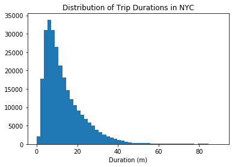

```python
## collect all of the trip times as a list ##
## and then use pyplot functions to generate a histogram of trip times.     ##
def NYC_trip_duration(filename):
    with open(filename, 'r') as f_in:
        # set up csv reader object
        reader = csv.DictReader(f_in)
        trip_time = []
        for row in reader:
            triptime = float(row['duration'])
            trip_time.append(triptime)

    return trip_time

NYC_time = NYC_trip_duration('./data/NYC-2016-Summary.csv')
plt.hist(NYC_time, 50, range=[0, 90])
plt.title('Distribution of Trip Durations in NYC')
plt.xlabel('Duration (m)')
plt.show()
```

**The questions that we need answers for**: What is the distribution of trip times for the Subscribers and the Customers in NYC. On top of that, how does it look like if the trip duration is less than 75 minutes? For each group, where is the peak of each distribution? How would you describe the shape of each distribution?

**Answer**:  
In NYC, the peak for the subscribers group is 5~10 minutes. The distribution is skewed to the right, which indicates that there are more datapoints on the right hand side. On the other hand, the peak for the customers group is 20~25 minutes. The distribution is also skewed to the right, but it looks more like a noraml distribution when being compared to the subscribers group.

```python
## load the numpy package. ##
import numpy as np

## get the durations for trips that last less than 75 minutes. ##
def mins75_trip_duration(filename):
    with open(filename, 'r') as f_in:
        # set up csv reader object
        reader = csv.DictReader(f_in)
        subscribers_trip_time = []
        customers_trip_time = []
        for row in reader:
            user_type = row['user_type']
            duration = float(row['duration'])
            if user_type == 'Subscriber' and duration < 75:
                subscribers_trip_time.append(duration)
            elif user_type == 'Customer' and duration < 75:
                customers_trip_time.append(duration)

    return (subscribers_trip_time, customers_trip_time)
```

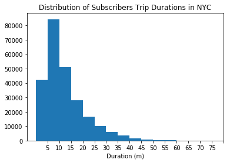

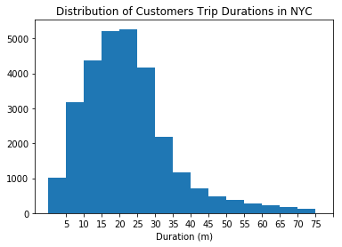

```python
NYC_subscribers_time, NYC_customers_time = mins75_trip_duration('./data/NYC-2016-Summary.csv')
bins = np.arange(0, 76, 5)
locations = bins + 5
labels = ['5','10','15','20','25','30','35','40','45','50','55','60','65','70','75']

plt.hist(NYC_subscribers_time, bins)
plt.xticks(locations, labels)
plt.title('Distribution of Subscribers Trip Durations in NYC')
plt.xlabel('Duration (m)')
plt.show()

plt.hist(NYC_customers_time, bins)
plt.xticks(locations, labels)
plt.title('Distribution of Customers Trip Durations in NYC')
plt.xlabel('Duration (m)')
plt.show()
```

## Further Analysis

So far, we've performed an initial exploration into the data available. We have compared the relative volume of trips made between three U.S. cities and the ratio of trips made by Subscribers and Customers. For one of these cities, we have investigated differences between Subscribers and Customers in terms of how long a typical trip lasts. Now we are going to further explore.

**The questions that I hope to get answers for**:  
As a business owner of the bike-share service, I'd ask:

1. Is there any seasonalities?  
   From the graphs we plotted, we can tell that there is indeed a seasonality. Although there are differences, the monthly usage on bike-share services converges in the middle of a year among all 3 cities. Most of the usage occurs between June and October, which are months during summer and fall. Put it another way, not that much usage during cold/ chilly season, which is the winter time. This is consistent for both subscribers and customers. This makes sense because the cities in our analysis are all located on the East Coast, in which winter could get really tough. One of the factors that could hugely impacts the usage is the occurence of snow storm.
2. What are the peak hours during a day?  
   From the graphs we plotted, we can tell that there is a big difference on hourly bike usage between subscribers and customers. For subscribers, the peak hours are 7-8 in the monrning and 17-18 in the evening, which are pretty much the time people go to/ get off work. For customers, the peak hours converge towards the middle of a day, in general from noon to 15 in the afternoon. This pattern is consistent among the 3 cities. Although further analysis is needed for drawing a conclusion, we could sort of tell that bike-share subscription may be more attractive to work force based on this preliminary investigation.

```python
# Load additional packages for further analysis
import pandas as pd
import seaborn as sns

# Load datasets as dataframe
dc = pd.read_csv('./data/Washington-2016-Summary.csv')
chi = pd.read_csv('./data/Chicago-2016-Summary.csv')
nyc = pd.read_csv('./data/NYC-2016-Summary.csv')
```

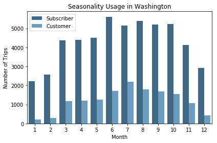

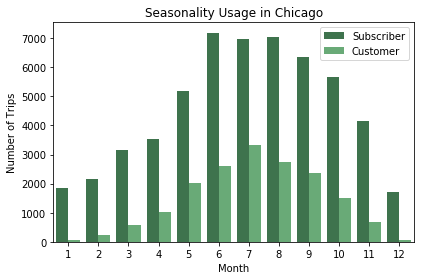

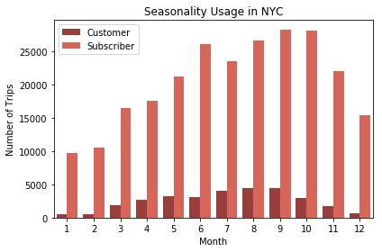

```python
## seasonality usage in 3 cities ##

# the number of trips for Washington
sns.countplot(x='month', data=dc, hue='user_type', palette='Blues_d')
plt.title('Seasonality Usage in Washington')
plt.xlabel('Month')
plt.ylabel('Number of Trips')
plt.legend()
plt.tight_layout()
plt.show()

# the number of trips for Chicago
sns.countplot(x='month', data=chi, hue='user_type', palette='Greens_d')
plt.title('Seasonality Usage in Chicago')
plt.xlabel('Month')
plt.ylabel('Number of Trips')
plt.legend()
plt.tight_layout()
plt.show()

# the number of trips for NYC
sns.countplot(x='month', data=nyc, hue='user_type', palette='Reds_d')
plt.title('Seasonality Usage in NYC')
plt.xlabel('Month')
plt.ylabel('Number of Trips')
plt.legend()
plt.tight_layout()
plt.show()
```

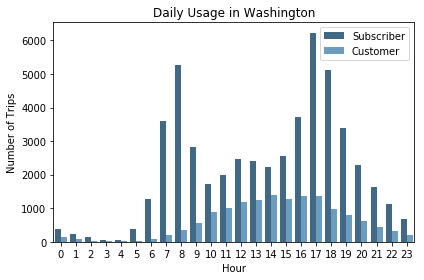

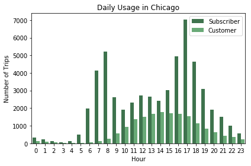

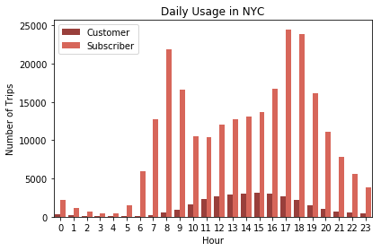

```python
## daily usage in 3 cities ##

# the number of trips for Washington
sns.countplot(x='hour', data=dc, hue='user_type', palette='Blues_d')
plt.title('Daily Usage in Washington')
plt.xlabel('Hour')
plt.ylabel('Number of Trips')
plt.legend()
plt.tight_layout()
plt.show()

# the number of trips for Chicago
sns.countplot(x='hour', data=chi, hue='user_type', palette='Greens_d')
plt.title('Daily Usage in Chicago')
plt.xlabel('Hour')
plt.ylabel('Number of Trips')
plt.legend()
plt.tight_layout()
plt.show()

# the number of trips for NYC
sns.countplot(x='hour', data=nyc, hue='user_type', palette='Reds_d')
plt.title('Daily Usage in NYC')
plt.xlabel('Hour')
plt.ylabel('Number of Trips')
plt.legend()
plt.tight_layout()
plt.show()
```

## Conclusions

This is only a sampling of the data analysis process: from generating questions, wrangling the data, and to exploring the data. Normally, at this point in the data analysis process, we might want to draw conclusions about the data by performing a statistical test or fitting the data to a model for making predictions. There are also a lot of potential analyses that could be performed on the data which are not possible with only the data provided. For example, detailed location data has not been investigated. Where are the most commonly used docks? What are the most common routes? As another example, weather has potential to have a large impact on daily ridership. How much is ridership impacted when there is rain or snow? Are subscribers or customers affected more by changes in weather?

```python
from subprocess import call
call(['python', '-m', 'nbconvert', 'Bike_Share_Analysis.ipynb'])
```

```
0
```